# **Music Recommendation System**

# **Milestone 1**

## **Problem Definition**

**The context** - Why is this problem important to solve?

- Spotify is one such audio content provider with a huge market base across the world. With the ever-increasing volume of songs becoming available on the Internet, searching for songs of interest has become a tedious task in itself.
- Spotify has grown significantly in the market because of its ability to recommend the ‘best’ next song to each and every customer based on a huge preference database gathered over time - millions of customers and billions of songs. This is done by using smart recommendation systems that can recommend songs based on users’ likes/dislikes.

**The objectives** - What is the intended goal?

- To improve customer satisfaction and hence improve revunue, the data scientist at Spotify need to build a recommendation system to propose the top 10 songs for a user based on the likelihood of listening to those songs.

**The key questions** - What are the key questions that need to be answered?

To build a recommendation system:

- Do we have the datasets related to users and songs?
- Do we have to obtain the datasets by our selves or will they be provided by other teams?
- In case, we have to obtain the data by ourselves, do have access to database which stores the database tables?
- What features do we need related to users and songs?
- What is the quality of the data? For instance, what is the percentage of missing values in the data?
- How should we treat the missing values?
- What is datatypes of the features? Which features are categorical and which ones are numerical? Do we need to perform one-hot encoding?
- Is there any feature that is redundant or do not add any value to the model?
- Do we need to do any feauture reduction in case of too many features?
- What additional features realted to users and songs would be benefical to have?
- Removing the noise from the data: Do we need to apply any filtering to dataset? Should we treat every song and user the same?
- Do we need to do any feature engineering?
- Is the data size enough?
- Given the data available what algorithms and techniques can be utilized?
- What is the size training and test datasets?
- Giving the business objective for model evaluation what metrics should be focused? Precision, recall or F1 Score metrics?
- What should be the definition of false postive and false negative based on the business objective?
- What algorithm to compute similarity metric?

**The problem formulation** - What is it that we are trying to solve using data science?

Recommender systems act as skilled agents to assist users to conquer information overload while making selection decisions over items by providing customized recommendations. Users and items are general phrases denoting, respectively, entities actively browsing and making choices and entities being selected, such as goods and services.

The core techniques or algorithms for realizing recommender systems are generally classified into four categories: popularity based filtering, content-based filtering, collaborative filtering, and hybrid filtering

Content-based filtering generates recommendations based on properties of items and user-item interactions. Collaborative filtering strives to identify a group of users with similar preferences based on past user-item interactions and recommends items preferred by these users.

Hybrid filtering is the extension or combination of content-based and collaborative filtering.

Spotify need to build a recommendation system to propose the top 10 songs for a user based on the likelihood of listening to those songs so that company can keep the users (and therefore investors) happy, stay competitive in the market and increase the revenues.

## **Data Dictionary**

The core data is the Taste Profile Subset released by The Echo Nest as part of the Million Song Dataset. There are two files in this dataset. One contains the details about the song id, titles, release, artist name and the year of release. Second file contains the user id, song id and the play count of users.

song_data

song_id - A unique id given to every song

title - Title of the song

Release - Name of the released album

Artist_name - Name of the artist

year - Year of release

count_data

user _id - A unique id given to the user

song_id - A unique id given to the song

play_count - Number of times the song was played

## **Data Source**

http://millionsongdataset.com/

## **Important Notes**

- This notebook can be considered a guide to refer to while solving the problem. The evaluation will be as per the Rubric shared for each Milestone. Unlike previous courses, it does not follow the pattern of the graded questions in different sections. This notebook would give you a direction on what steps need to be taken in order to get a viable solution to the problem. Please note that this is just one way of doing this. There can be other 'creative' ways to solve the problem and we urge you to feel free and explore them as an 'optional' exercise.
- In the notebook, there are markdown cells called - Observations and Insights. It is a good practice to provide observations and extract insights from the outputs.
- The naming convention for different variables can vary. Please consider the code provided in this notebook as a sample code.
- All the outputs in the notebook are just for reference and can be different if you follow a different approach.
- There are sections called **Think About It** in the notebook that will help you get a better understanding of the reasoning behind a particular technique/step. Interested learners can take alternative approaches if they want to explore different techniques.

### **Importing Libraries and the Dataset**

```python
#Mounting the drive
from google.colab import drive
drive.mount('/content/drive')
```

```python
import warnings #Used to ignore the warning given as output of the code.
warnings.filterwarnings('ignore')

import numpy as np # Basic libraries of python for numeric and dataframe computations.
import pandas as pd

import matplotlib.pyplot as plt #Basic library for data visualization.
import seaborn as sns #Slightly advanced library for data visualization

from sklearn.metrics.pairwise import cosine_similarity #To compute the cosine similarity between two vectors.
from collections import defaultdict #A dictionary output that does not raise a key error

from sklearn.metrics import mean_squared_error # A performance metrics in sklearn.
```

```python
#importing the datasets
count_df = pd.read_csv('/content/drive/MyDrive/count_data.csv')
song_df = pd.read_csv('/content/drive/MyDrive/song_data.csv')
```

- Addition to notebook

```python
# Copying the data to another DataFrame

"""" Note: When deep=True (default), a new object will be created with a
copy of the calling object's data and indices. Modifications to
the data or indices of the copy will not be reflected in the
original object (see notes below).

When deep=False, a new object will be created without copying
the calling object's data or index (only references to the data
and index are copied). Any changes to the data of the original
will be reflected in the shallow copy (and vice versa)."""

df_copy_count = count_df.copy(deep = True)
df_copy_song = song_df.copy(deep = True)
```

### **Understanding the data by viewing a few observations**

```python
# See top 10 records of count_df data
count_df.head(10)
```

|  | Unnamed: 0 | user_id | song_id | play_count |
| --- | --- | --- | --- | --- |
| 0 | 0 | b80344d063b5ccb3212f76538f3d9e43d87dca9e | SOAKIMP12A8C130995 | 1 |
| 1 | 1 | b80344d063b5ccb3212f76538f3d9e43d87dca9e | SOBBMDR12A8C13253B | 2 |
| 2 | 2 | b80344d063b5ccb3212f76538f3d9e43d87dca9e | SOBXHDL12A81C204C0 | 1 |
| 3 | 3 | b80344d063b5ccb3212f76538f3d9e43d87dca9e | SOBYHAJ12A6701BF1D | 1 |
| 4 | 4 | b80344d063b5ccb3212f76538f3d9e43d87dca9e | SODACBL12A8C13C273 | 1 |
| 5 | 5 | b80344d063b5ccb3212f76538f3d9e43d87dca9e | SODDNQT12A6D4F5F7E | 5 |
| 6 | 6 | b80344d063b5ccb3212f76538f3d9e43d87dca9e | SODXRTY12AB0180F3B | 1 |
| 7 | 7 | b80344d063b5ccb3212f76538f3d9e43d87dca9e | SOFGUAY12AB017B0A8 | 1 |
| 8 | 8 | b80344d063b5ccb3212f76538f3d9e43d87dca9e | SOFRQTD12A81C233C0 | 1 |
| 9 | 9 | b80344d063b5ccb3212f76538f3d9e43d87dca9e | SOHQWYZ12A6D4FA701 | 1 |

```python
# See top 10 records of song_df data
song_df.head(10)
```

|  | song_id | title | release | artist_name | year |
| --- | --- | --- | --- | --- | --- |
| 0 | SOQMMHC12AB0180CB8 | Silent Night | Monster Ballads X-Mas | Faster Pussy cat | 2003 |
| 1 | SOVFVAK12A8C1350D9 | Tanssi vaan | Karkuteillä | Karkkiautomaatti | 1995 |
| 2 | SOGTUKN12AB017F4F1 | No One Could Ever | Butter | Hudson Mohawke | 2006 |
| 3 | SOBNYVR12A8C13558C | Si Vos Querés | De Culo | Yerba Brava | 2003 |
| 4 | SOHSBXH12A8C13B0DF | Tangle Of Aspens | Rene Ablaze Presents Winter Sessions | Der Mystic | 0 |
| 5 | SOZVAPQ12A8C13B63C | Symphony No. 1 G minor "Sinfonie Serieuse"/All... | Berwald: Symphonies Nos. 1/2/3/4 | David Montgomery | 0 |
| 6 | SOQVRHI12A6D4FB2D7 | We Have Got Love | Strictly The Best Vol. 34 | Sasha / Turbulence | 0 |
| 7 | SOEYRFT12AB018936C | 2 Da Beat Ch'yall | Da Bomb | Kris Kross | 1993 |
| 8 | SOPMIYT12A6D4F851E | Goodbye | Danny Boy | Joseph Locke | 0 |
| 9 | SOJCFMH12A8C13B0C2 | Mama_ mama can't you see ? | March to cadence with the US marines | The Sun Harbor's Chorus-Documentary Recordings | 0 |

### **Let us check the data types and and missing values of each column**

```python
# See the info of the count_df data
count_df.info()
```

```
<class 'pandas.core.frame.DataFrame'>
RangeIndex: 2000000 entries, 0 to 1999999
Data columns (total 4 columns):
 #   Column      Dtype
---  ------      -----
 0   Unnamed: 0  int64
 1   user_id     object
 2   song_id     object
 3   play_count  int64
dtypes: int64(2), object(2)
memory usage: 61.0+ MB
```

```python
# See the info of the song_df data
song_df.info()
```

```
<class 'pandas.core.frame.DataFrame'>
RangeIndex: 1000000 entries, 0 to 999999
Data columns (total 5 columns):
 #   Column       Non-Null Count    Dtype
---  ------       --------------    -----
 0   song_id      1000000 non-null  object
 1   title        999985 non-null   object
 2   release      999995 non-null   object
 3   artist_name  1000000 non-null  object
 4   year         1000000 non-null  int64
dtypes: int64(1), object(4)
memory usage: 38.1+ MB
```

- Addition to Notebook

```python
# GEO - Count the number null values in count_df dataset
count_df.isnull().sum()
```

```
Unnamed: 0    0
user_id       0
song_id       0
play_count    0
dtype: int64
```

```python
# GEO - Count the number null values in count_df dataset
song_df.isnull().sum()
```

```
song_id         0
title          15
release         5
artist_name     0
year            0
dtype: int64
```

```python
# GEO - Locate null rows in a dataframe (song_df)
is_NaN = song_df.isnull()
row_has_NaN = is_NaN.any(axis=1)
rows_with_NaN = song_df[row_has_NaN]

print(rows_with_NaN)
```

```
                   song_id                     title  \
64262   SOVICLT12A58A7C4D0                       NaN
114672  SOAGRAA12AB018D567                       NaN
138011  SOOBGAQ12A6D4F6762                  Solitude
197822  SOGFJER12A6D4F675F  All The Beautiful People
223019  SOAFJBH12A6D4F6765           Down The Aisles
229353  SOOAFJX12AB018A028                       NaN
264639  SOLDTFD12AB018AFE6                       NaN
458083  SOAUTVB12AB018AFF0                       NaN
557125  SOMPGYE12AB018AFE0                       NaN
578241  SOVHAZH12AB018D5B3                       NaN
652287  SOECGBQ12AB018D582                       NaN
693232  SOCKQGJ12A6D4F6768                Provincial
697789  SOTJWHR12AB018D5A0                       NaN
697813  SOBDDHR12AB01888A6                       NaN
```

[output cut: 28 more lines]

#### **Observations and Insights:**

- There are 2 datasets (count_data and song_data) provided to create recommendation system.
- After loading the datasets, created dataframes and in addition created copies of the dataframes.
- Checked the record counts, # of rows, # of columns, data types, missing values, memory usage in each data frame.

**Count_df:**

- 2000000 rows and 4 columns,
- Column names: "Unnamed: 0", "user_id", "song_id", "play_count"
- user_id and song_id have object data types and Unnamed: 0 and play_count columns have integer data types.
- Delete the "Unnamed: 0" column since this column does not add any value

**Song_df:**

- 1000000 rows and 5 columns,
- Column names: "song_id", "title", "release", "artist_name", "year"
- 4 columns have object data types and 1 column has integer datatype.
- Year column has integer data type - can be converted to date datatype.
- title and realease columns have some missing values (15 and 5 respecfully).
  - We could delete the rows with missing values.
  - "year" column has values as "0". "0" values can be deleted from the year column.

```python
# GEO- Drop Rows with missing values from song_df dataset and check the shape of the dataset.
# The dataset is too large to print. Therefore, instead of print function utilized shape function.
# print(song_df) vs song_df.shape

song_df.shape
song_df.dropna( how='any', inplace=True)
song_df.shape
```

```
(999980, 5)
```

```python
# Left merge the count_df and song_df data on "song_id". Drop duplicates from song_df data simultaneously.

# Drop the column 'Unnamed: 0'


df= pd.merge(count_df, song_df.drop_duplicates(['song_id']), on="song_id", how="left")

df= df.drop(['Unnamed: 0'], axis = 1)
```

```python
df.head(2)
```

|  | user_id | song_id | play_count | title | release | artist_name | year |
| --- | --- | --- | --- | --- | --- | --- | --- |
| 0 | b80344d063b5ccb3212f76538f3d9e43d87dca9e | SOAKIMP12A8C130995 | 1 | The Cove | Thicker Than Water | Jack Johnson | 0 |
| 1 | b80344d063b5ccb3212f76538f3d9e43d87dca9e | SOBBMDR12A8C13253B | 2 | Entre Dos Aguas | Flamenco Para Niños | Paco De Lucia | 1976 |

**Think About It:** As the user_id and song_id are encrypted. Can they be encoded to numeric features?

```python
# Apply label encoding for "user_id" and "song_id"

# There are 2 methods to convert categorical varialable to a form that best used for ML algorithms: Label encoding and one hot encoding.
# I would prefer to convert categorical variables after completing EDA analysis.

# Import label encoder
from sklearn import preprocessing

le1 = preprocessing.LabelEncoder()
le2 = preprocessing.LabelEncoder()
df['user_id'] = le1.fit_transform(df['user_id'].astype(str))
df['song_id'] = le2.fit_transform(df['song_id'].astype(str))
df.head(2)
```

|  | user_id | song_id | play_count | title | release | artist_name | year |
| --- | --- | --- | --- | --- | --- | --- | --- |
| 0 | 54961 | 153 | 1 | The Cove | Thicker Than Water | Jack Johnson | 0 |
| 1 | 54961 | 413 | 2 | Entre Dos Aguas | Flamenco Para Niños | Paco De Lucia | 1976 |

**Think About It:** As the data also contains users who have listened to very few songs and vice versa, is it required to filter the data so that it contains users who have listened to a good count of songs and vice versa?

```python
# Get the column containing the users
users = df.user_id
# Create a dictionary from users to their number of songs
ratings_count = dict()
for user in users:
    # If we already have the user, just add 1 to their rating count
    if user in ratings_count:
        ratings_count[user] += 1
    # Otherwise, set their rating count to 1
    else:
        ratings_count[user] = 1
```

```python
# We want our users to have listened at least 90 songs
RATINGS_CUTOFF = 90
remove_users = []
for user, num_ratings in ratings_count.items():
    if num_ratings < RATINGS_CUTOFF:
        remove_users.append(user)
df = df.loc[~df.user_id.isin(remove_users)]
```

```python
# Get the column containing the songs
songs = df.song_id
# Create a dictionary from songs to their number of users
ratings_count = dict()
for song in songs:
    # If we already have the song, just add 1 to their rating count
    if song in ratings_count:
        ratings_count[song] += 1
    # Otherwise, set their rating count to 1
    else:
        ratings_count[song] = 1
```

```python
# We want our song to be listened by atleast 120 users to be considred
RATINGS_CUTOFF = 120
remove_songs = []
for song, num_ratings in ratings_count.items():
    if num_ratings < RATINGS_CUTOFF:
        remove_songs.append(song)
df_final= df.loc[~df.song_id.isin(remove_songs)]
```

```python
# Check shape before drop
df_final.shape
```

```
(130398, 7)
```

```python
# Drop records with play_count more than(>) 5

df_filtered = df_final[df_final['play_count'] > 5]
print(df_filtered)
len(df_filtered)

df_final= df_final.loc[df_final['play_count'] >5]
df_final.shape
```

[output not shown]

[output cut: 25 more lines]

```
(12522, 7)
```

```python
df_final.head(5)
```

[output not shown]

```python
df_final.sort_values(by='play_count', ascending=False)
```

[output not shown]

12522 rows × 7 columns

```python
# Check the shape of the data
df_final.shape
```

```
(12522, 7)
```

## **Exploratory Data Analysis**

### **Let's check the total number of unique users, songs, artists in the data**

Total number of unique user id

```python
# Display total number of unique user_id
# Method 1

users = df_final['user_id'].unique()
len(users) ## returns # of unique user id's
```

```
2187
```

```python
# Display total number of unique user_id
# Method 2
df_final.user_id.describe()
```

[output not shown]

Total number of unique song id

```python
# Display total number of unique song_id
songs = df_final['song_id'].unique()
len(songs) ## returns # of unique song id's
```

```
555
```

Total number of unique artists

```python
# Display total number of unique artists
artists = df_final['artist_name'].unique()
len(artists) ## returns # of unique artist names
```

```
232
```

#### **Observations and Insights:**__****

There are 2187 unique users, 555 unique song_ids and 232 unique artists.

### **Let's find out about the most interacted songs and interacted users**

Most interacted songs

```python
df_final.groupby('song_id').play_count.sum().sort_values(ascending=False).head(10)
```

[output not shown]

Most interacted users

```python
df_final.groupby('user_id').play_count.sum().sort_values(ascending=False).head(10)
```

[output not shown]

```python
df_final.groupby('user_id').song_id.count().sort_values(ascending=False).head(20)
```

[output not shown]

After applying one hot encoding we may run below syntax to display # of times songs listen to by each users

df_final.groupby('user_id').song_id.sum().sort_values(ascending=False).head(20)

#### **Observations and Insights:**___****

- Most interacted songs has song_ID "SOAUWYT12A81C206F1".
- Most interacted user has user_id "4be305e02f4e72dad1b8ac78e630403543bab994".

Songs played in a year

```python
# Songs played in a year
count_songs = df_final.groupby('year').count()['title']
count = pd.DataFrame(count_songs)
count.drop(count.index[0], inplace=True)
count.tail()
```

| year | title |
| --- | --- |
| 2006 | 586 |
| 2007 | 896 |
| 2008 | 1214 |
| 2009 | 1609 |
| 2010 | 395 |

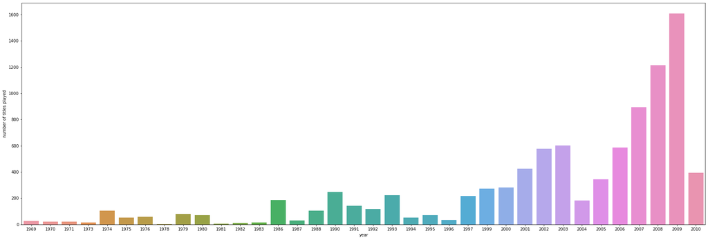

```python
plt.figure(figsize=(30,10))
sns.barplot(x = count.index,
            y = 'title',
            data = count,
            estimator = np.median)
plt.ylabel('number of titles played')
# Show the plot
plt.show()
```

#### **Observations and Insights:**__****

Based on the year of song lease and title distibution, 2009 was the most popular.

**Think About It:** What other insights can be drawn using exploratory data analysis?

By applying feature engineering techniques varios exploratory analysis can be performed. For instance by merging songs and artist columns, we could find out which of songs of artist were mostly played mostly.

Amonged the released albums which song's were most popular?

Which song's of each artist's were least listened to?

If we had feautures such as gender and age related to user, we could have done EDA analysis based on those features and suggest songs based on gender and age engagements.

PCA and tSNA analysis can be performed to find similar user groups.

## **Proposed approach**

**Potential techniques** - What different techniques should be explored?

We may build a recommendation system based on popularity filtering, content filtering, collabrative filtering and hybrid filtering.

Popularity based filtering In this filtering strategy the suggested songs will be based on the popularity or trend.

Disdvantages Not personalized to users Only takes popularity in account

Content-based Filtering This filtration strategy is based on the data provided about the items. The algorithm recommends products that are similar to the ones that a user has liked in the past. This similarity (generally cosine similarity) is computed from the data we have about the items as well as the user’s past preferences.

Disadvantages Different products do not get much exposure to the user. Businesses cannot be expanded as the user does not try different types of products.

Collaborative Filtering This filteration strategy is based on the combination of the user’s behavior and comparing and contrasting that with other users’ behavior in the database. The history of all users plays an important role in this algorithm. The main difference between content-based filtering and collaborative filtering that in the latter, the interaction of all users with the items influences the recommendation algorithm while for content-based filtering only the concerned user’s data is taken into account. There are multiple ways to implement collaborative filtering but the main concept to be grasped is that in collaborative filtering multiple user’s data influences the outcome of the recommendation. and doesn’t depend on only one user’s data for modeling. There are 2 types of collaborative filtering algorithms:

User-based Collaborative filtering The basic idea here is to find users that have similar past preference patterns as the user ‘A’ has had and then recommending him or her items liked by those similar users which ‘A’ has not encountered yet. This is achieved by making a matrix of items each user has rated/viewed/liked/clicked depending upon the task at hand, and then computing the similarity score between the users and finally recommending items that the concerned user isn’t aware of but users similar to him/her are and liked it.

Disadvantages

People are fickle-minded i.e their taste change from time to time and as this algorithm is based on user similarity it may pick up initial similarity patterns between 2 users who after a while may have completely different preferences. There are many more users than items therefore it becomes very difficult to maintain such large matrices and therefore needs to be recomputed very regularly. This algorithm is very susceptible to shilling attacks where fake users profiles consisting of biased preference patterns are used to manipulate key decisions.

Item-based Collaborative Filtering The concept in this case is to find similar songs instead of similar users and then recommending similar movies to that ‘A’ has had in his/her past preferences.

Advantages over User-based Collaborative Filtering Unlike people’s taste, movies don’t change. There are usually a lot fewer items than people, therefore easier to maintain and compute the matrices. Shilling attacks are much harder because items cannot be faked.

**Overall solution design** - What is the potential solution design?

Prediction problem

Provided a list of N user M items, Given user i and item j, find the likelihood of i matching with j using historical matchings or preferences.

Steps:

Data Preparation

EDA Analysis and Feature Engineering

Removing Noise in Data

PCA or TSNA Analysis

Data Standardization

Removing Sparsity

Matrix Estimation

Splitting Data into 2 Different Datasets: Train and Test

Buildig the Model

Using the KNN algorithm to compute similarity with cosine distance metric

Definition of Business Metrics to Evaluate Model Performance

Model Tunning

Checking on the Errors, Tunning Hyper-Parameters

Comparising Train and Test Model Performance

Coming Up with Best List of Songs to Recommend.

**Measures of success**- What are the key measures of success to compare different potential technqiues?

Common Metrics Used Predictive accuracy metrics, classification accuracy metrics, rank accuracy metrics, and non-accuracy measurements are the four major types of evaluation metrics for recommender systems.

Predictive Accuracy Metrics Predictive accuracy or rating prediction measures address the subject of how near a recommender’s estimated ratings are to genuine user ratings. This sort of measure is widely used for evaluating non-binary ratings.

It is best suited for usage scenarios in which accurate prediction of ratings for all products is critical. Mean Absolute Error (MAE), Mean Squared Error (MSE), Root Mean Squared Error (RMSE), and Normalized Mean Absolute Error (NMAE) are the most important measures for this purpose.

In comparison to the MAE metric, MSE and RMSE employ squared deviations and consequently emphasize bigger errors. The error is described by MAE and RMSE in the same units as the obtained data, whereas MSE produces squared units.

To make results comparable among recommenders with different rating scales, NMAE normalizes the MAE measure to the range of the appropriate rating scale. In the Netflix competition, the RMSE measure was utilized to determine the improvement in comparison to the Cinematch algorithm, as well as the prize winner.

Classification Accuracy Metrics Classification accuracy measures attempt to evaluate a recommendation algorithm’s successful decision-making capacity (SDMC). They are useful for user tasks such as identifying nice products since they assess the number of right and wrong classifications as relevant or irrelevant things generated by the recommender system.

Rank Accuracy Metrics In statistics, a rank accuracy or ranking prediction metric assesses a recommender’s ability to estimate the correct order of items based on the user’s preferences, which is known as rank correlation measurement. As a result, if the user is given a long, sorted list of goods that are recommended to him, this type of measure is most appropriate.

Mean Average Precision @ K and Mean Average Recall @ K

For each user in the test set, a recommender system normally generates an ordered list of recommendations. MAP@K indicates how relevant the list of recommended items is, whereas MAR@K indicates how well the recommender can recall all of the items in the test set that the user has rated positively.

Apart from all of this, we can also leverage our standard ML evaluation metrics to evaluate ratings and predictions that are as follows.

Precision Recall F1-measure False-positive rate Mean average precision Mean absolute error The area under the ROC curve (AUC)